# Spatial@iDiv - Day 1

Isabel Rosa

05/11/2018

## Introduction to R (skip if not needed)

Very brief introduction to the use of R.

```r
# assigning variables
x <- 1
y <- 2

# mathematical operations
x + y
```

```
## [1] 3
```

```r
x * y
```

```
## [1] 2
```

```r
x - y
```

```
## [1] -1
```

```r
x / y
```

```
## [1] 0.5
```

```r
# logical operations
x == 10
```

```
## [1] FALSE
```

```r
x > 2
```

```
## [1] FALSE
```

```r
x < 2
```

```
## [1] TRUE
```

```r
x >= 1
```

```
## [1] TRUE
```

```r
x <= 1
```

```
## [1] TRUE
```

```r
# check object type
str(x)
```

```
##  num 1
```

```r
is.matrix(y)
```

```
## [1] FALSE
```

```r
typeof(x)
```

```
## [1] "double"
```

```r
class(x)
```

```
## [1] "numeric"
```

```r
# vectors, matrices and data frames
vXY <- c(x, y)
new_vec <- c(1,2,3,4,5)
new_mat <- cbind(new_vec, new_vec)

# generates 2 x 3 numeric matrix
y<-matrix(1:6, nrow=2,ncol=3)
y1<-matrix(1:6, nrow=2,ncol=3, byrow=T) # by rows
y2<-matrix(1:6, nrow=2,ncol=3, byrow=F) # by columns

# operations with matrices
colSums(new_mat) #sum all values in each column
```

```
## new_vec new_vec
##      15      15
```

```r
rowSums(new_mat) #sum all values in each row
```

```
## [1]  2  4  6  8 10
```

```r
t(new_mat) # transpose
```

```
##         [,1] [,2] [,3] [,4] [,5]
## new_vec    1    2    3    4    5
## new_vec    1    2    3    4    5
```

```r
new_mat + 2 # add a constant to each element in the matrix
```

```
##      new_vec new_vec
## [1,]       3       3
## [2,]       4       4
## [3,]       5       5
## [4,]       6       6
## [5,]       7       7
```

```r
new_mat * 0.5 # multiplies a constant to each element in the matrix
```

```
##      new_vec new_vec
## [1,]     0.5     0.5
## [2,]     1.0     1.0
## [3,]     1.5     1.5
## [4,]     2.0     2.0
## [5,]     2.5     2.5
```

```r
new_mat ^ 2
```

```
##      new_vec new_vec
## [1,]       1       1
## [2,]       4       4
## [3,]       9       9
## [4,]      16      16
## [5,]      25      25
```

```r
# adding characters
z <- c("A", "B", "C", "D", "E")
new_mat2<-cbind(new_mat,z) # notice what happens
#new_mat2[,1]+10

# convert matrix to data.frame
new_mat2<-data.frame(new_mat2)
is.data.frame(new_mat2)
```

```
## [1] TRUE
```

```r
new_mat2[,1]+10
```

```
## [1] NA NA NA NA NA
```

```r
is.numeric(new_mat2$column1)
```

```
## [1] FALSE
```

```r
# flexibility of data.frames
df1<-data.frame(1:5,2:6,z)
df1<-data.frame(col1 = 1:5, col2 = 2:6, col3 = z)
df1$col1+10  # notice that we're not replacing the values in the data.frame
```

```
## [1] 11 12 13 14 15
```

```r
# modifying column values
df1$col1<-df1$col1 + 100
# create new column
df1$col4<-df1$col1 * 100

# changing column names
colnames(new_mat)
```

```
## [1] "new_vec" "new_vec"
```

```r
colnames(new_mat)<-c("column1", "column2")

# sequences using multiple commands, and a random uniform function
new_seq <- 1:10
new_seq2 <- seq(1, 10, 2)
runif(1)
```

```
## [1] 0.9995481
```

```r
new_seq3 <- runif(10)

# subset data using multiple options (first elements is the row number, second element is the column number)
new_vec[1]
```

```
## [1] 1
```

```r
head(new_vec, n = 1)
```

```
## [1] 1
```

```r
new_vec[length(new_vec)]
```

```
## [1] 5
```

```r
tail(new_vec, n = 1)
```

```
## [1] 5
```

```r
new_mat[1,2]
```

```
## column2
##       1
```

```r
head(new_mat,n=1)
```

```
##      column1 column2
## [1,]       1       1
```

```r
tail(new_mat,n=2)
```

```
##      column1 column2
## [4,]       4       4
## [5,]       5       5
```

```r
# select row based on logical operation
df1[df1$col3=="D",]
```

```
##   col1 col2 col3  col4
## 4  104    5    D 10400
```

```r
# replace elements based on logical operations
df1$col1[df1$col3=="D"]<-10
# find values and return their index (position in object)
which(df1$col1==10)
```

```
## [1] 4
```

```r
sum(df1$col1==10) # powerful trick TRUE == 1 and FALSE == 0
```

```
## [1] 1
```

```r
# this is the very basic to be able to complete the exercise today, and we'll keep learning R tricks as we go along
```

## Install and/or Load Packages

There are several packages useful to work with spatial data in R. During this course we’ll work mainly with five: sp: for working with vector data, raster: for working with raster data rgdal: for manipulating spatial data, such as changing coordinate systems rgeos: for operations with vectorial and raster data maptools: provides a set of geospatial data processing and analysis methods

```r
# if you need to install first any of the packages, use the following commands
#install.packages("raster")
#install.packages("rgdal")
#install.packages("sp")
#install.packages("rgeos")
#install.packages("maptools")

# load packages
library(raster)
library(rgdal)
library(sp)
library(rgeos)
library(maptools)
# auxiliary packages
library(RColorBrewer) # to help with coloring our maps
library(ggplot2) # to help producing nice plots
```

## Shapefiles and Rasters

When you work with spatial data, essentially you use two types of data:

1. vector data (i.e., shapefiles): stores the geometric location and attribute information of geographic features. These can be represented by points, lines, or polygons (areas).
2. matricial data (i.e., raster): consists of a matrix of cells (or pixels) organized into rows and columns (or a grid) where each cell contains a value representing information. They can be categorical or continuous and have multiple bands.

For more information see morning lecture: https://drive.google.com/drive/folders/1i6PQP-u7ky8mrShmbqykIw9WDw66wS6T

## Reference systems

1. geodesic/geographic coordinates need an order (lat/long), a unit (e.g., degrees) and a datum (a reference ellipsoid: e.g. WGS84)
2. cartesian/projected coordinates (e.g. UTM, web Mercator) need also measurement units (e.g., meters), and some way of encoding how they relate to geodesic coordinates, in which datum (this is handled by the GIS system)

[figure not shown]

## Working with Shapefiles in R

R is a very powerful to work with shapefiles and the data they contain. Here I will show you some examples, using the same case study that you worked on in the morning using ArcMap.

Download data from here (if you haven’t done it already!): https://drive.google.com/drive/folders/1Zdtz6LAFKY-mkiCiZ7DHTa4rRt7DwBg1

```r
# read in shapefile using rgdal
deaths <- readOGR(".", "Cholera_Deaths")
pumps <- readOGR(".", "Pumps")
# always good to check the contents of your dat
str(deaths)
```

```
## Formal class 'SpatialPointsDataFrame' [package "sp"] with 5 slots
##   ..@ data       :'data.frame':  250 obs. of  2 variables:
##   .. ..$ Id   : int [1:250] 0 0 0 0 0 0 0 0 0 0 ...
##   .. ..$ Count: int [1:250] 3 2 1 1 4 2 2 2 3 2 ...
##   ..@ coords.nrs : num(0)
##   ..@ coords     : num [1:250, 1:2] 529309 529312 529314 529317 529321 ...
##   .. ..- attr(*, "dimnames")=List of 2
##   .. .. ..$ : NULL
##   .. .. ..$ : chr [1:2] "coords.x1" "coords.x2"
##   ..@ bbox       : num [1:2, 1:2] 529160 180858 529656 181306
##   .. ..- attr(*, "dimnames")=List of 2
##   .. .. ..$ : chr [1:2] "coords.x1" "coords.x2"
##   .. .. ..$ : chr [1:2] "min" "max"
##   ..@ proj4string:Formal class 'CRS' [package "sp"] with 1 slot
##   .. .. ..@ projargs: chr "+proj=tmerc +lat_0=49 +lon_0=-2 +k=0.9996012717 +x_0=400000 +y_0=-100000 +ellps=airy +units=m +no_defs"
```

```r
str(pumps)
```

```
## Formal class 'SpatialPointsDataFrame' [package "sp"] with 5 slots
##   ..@ data       :'data.frame':  8 obs. of  1 variable:
##   .. ..$ Id: int [1:8] 0 0 0 0 0 0 0 0
##   ..@ coords.nrs : num(0)
##   ..@ coords     : num [1:8, 1:2] 529397 529193 529184 529749 529613 ...
##   .. ..- attr(*, "dimnames")=List of 2
##   .. .. ..$ : NULL
##   .. .. ..$ : chr [1:2] "coords.x1" "coords.x2"
##   ..@ bbox       : num [1:2, 1:2] 529184 180660 529749 181194
##   .. ..- attr(*, "dimnames")=List of 2
##   .. .. ..$ : chr [1:2] "coords.x1" "coords.x2"
##   .. .. ..$ : chr [1:2] "min" "max"
##   ..@ proj4string:Formal class 'CRS' [package "sp"] with 1 slot
##   .. .. ..@ projargs: chr "+proj=tmerc +lat_0=49 +lon_0=-2 +k=0.9996012717 +x_0=400000 +y_0=-100000 +ellps=airy +units=m +no_defs"
```

```r
# check the coordinate system of your shapefile
proj4string(deaths)
```

```
## [1] "+proj=tmerc +lat_0=49 +lon_0=-2 +k=0.9996012717 +x_0=400000 +y_0=-100000 +ellps=airy +units=m +no_defs"
```

```r
proj4string(pumps)
```

```
## [1] "+proj=tmerc +lat_0=49 +lon_0=-2 +k=0.9996012717 +x_0=400000 +y_0=-100000 +ellps=airy +units=m +no_defs"
```

```r
# they should all be the same!

#if missing: assign coordinates
#proj4string(deaths) <- CRS("+proj=tmerc +lat_0=49 +lon_0=-2 +k=0.9996012717 +x_0=400000 +y_0=-100000 +ellps=airy +units=m +no_defs")

#if different: transforms coordinates (here, hypotethically transforming to wgs84)
#deaths.wgs <- spTransform(deaths, CRS("+proj=longlat +datum=WGS84"))


# check top rows
head(deaths)
```

```
##   Id Count
## 1  0     3
## 2  0     2
## 3  0     1
## 4  0     1
## 5  0     4
## 6  0     2
```

```r
# total number of deaths
sum(deaths$Count)
```

```
## [1] 489
```

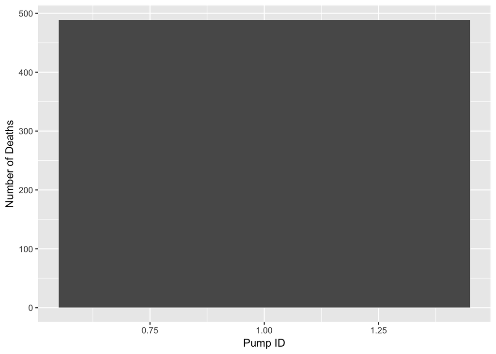

```r
# deaths per pump Id
df<-data.frame(ID = 1:length(unique(deaths$Id)),value = tapply(deaths$Count, deaths$Id, sum))

# barplot results
ggplot(data=df, aes(x=ID, y=value)) +
  geom_bar(stat="identity") +
  xlab("Pump ID")+
  ylab("Number of Deaths")
```

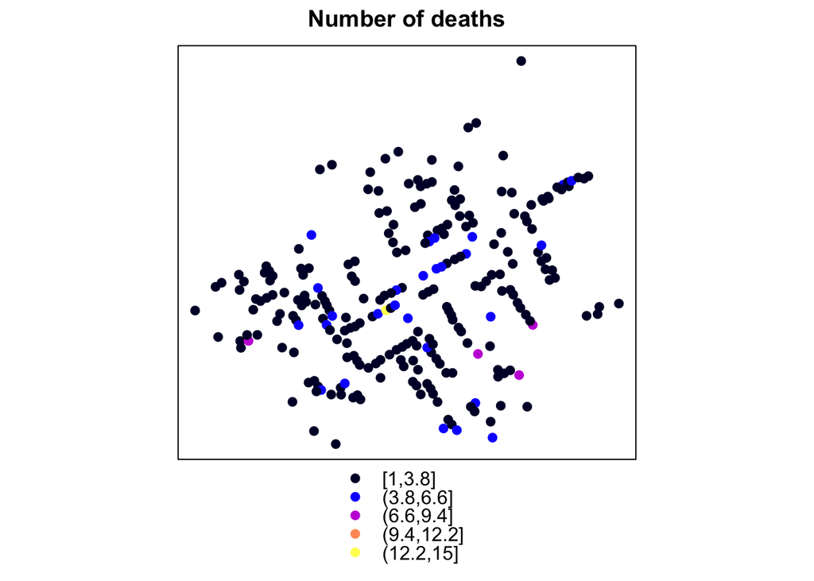

```r
# visualize one of the variables
spplot(deaths, z="Count", main = "Number of deaths")
```

```r
# read in raster
snowMap <-raster("SnowMap.tif")
NAvalue(snowMap)<-255 # why these values? See here for a simple but clear https://www.quora.com/Why-is-color-measured-on-a-scale-of-0-to-255

proj4string(snowMap) # check coordinates
```

```
## [1] "+proj=tmerc +lat_0=49 +lon_0=-2 +k=0.9996012717 +x_0=400000 +y_0=-100000 +datum=OSGB36 +units=m +no_defs +ellps=airy +towgs84=446.448,-125.157,542.060,0.1502,0.2470,0.8421,-20.4894"
```

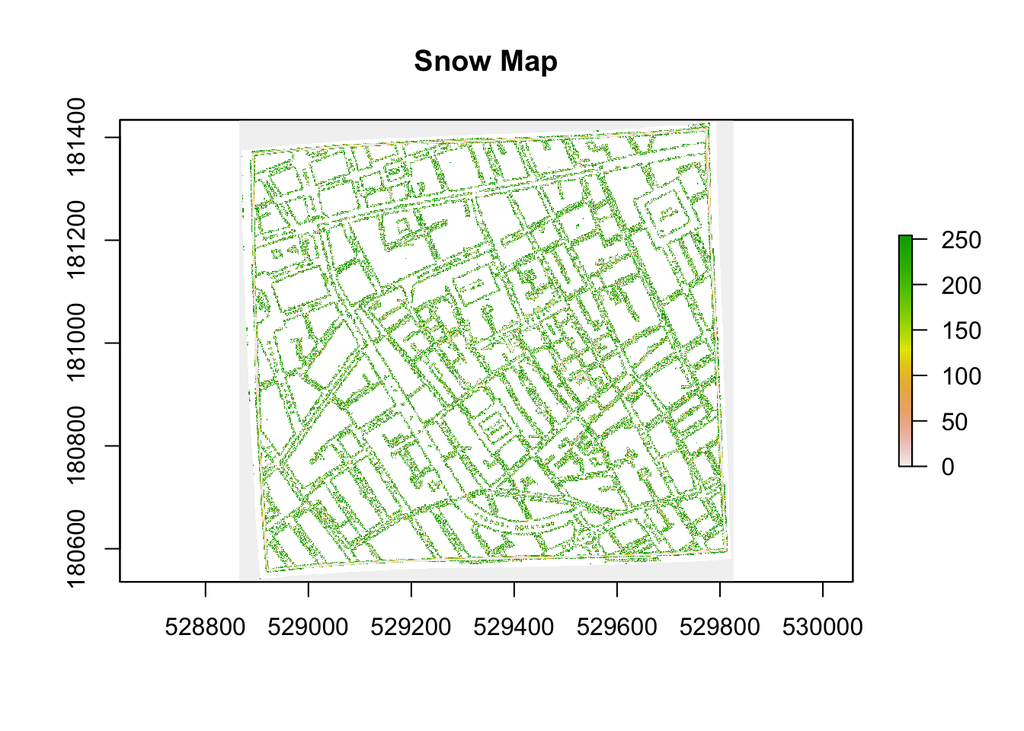

```r
# visualize Snow's map
plot(snowMap, main = "Snow Map") # deafult colors
```

[figure not shown]

```r
# change map colors
cuts<-seq(0,255,50) #set breaks
pal <- colorRampPalette(c("black","white"))
plot(snowMap, breaks=cuts, col = pal(7)) #plot with defined breaks

# put shapefiles on top of raster
plot(snowMap, breaks=cuts, col = pal(7)) #plot with defined breaks
plot(deaths, col="red", add=TRUE)
plot(pumps, col="blue", add=TRUE)
```

```r
# export your map
pdf("snowMap_withDeaths_and_Pumps.pdf")
plot(snowMap, breaks=cuts, col = pal(7)) #plot with defined breaks
plot(deaths, pch = 4, col="red", add=TRUE)
plot(pumps, pch = 25, col="blue", add=TRUE)
dev.off()
```

## Operations with Shapefiles

We will just explore a few options during these days in the course, but there are multiple functions that you can use to work with shapefiles in R. Have a look at this great tutorial: http://www.rspatial.org/spatial/rst/7-vectmanip.html

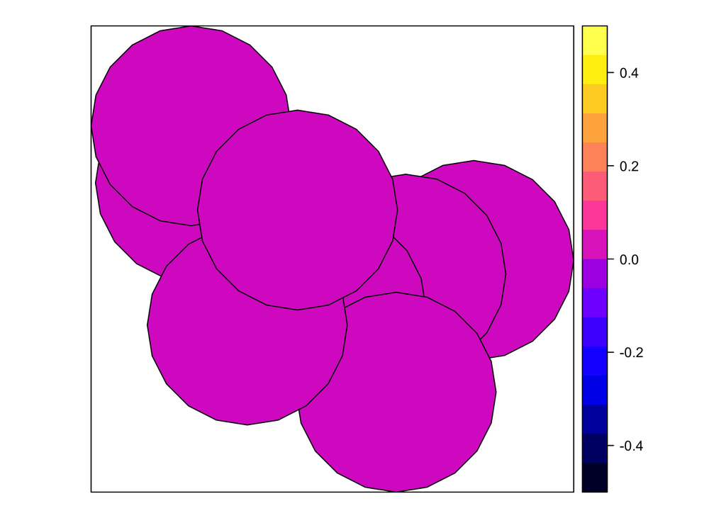

```r
# let's create the buffers of 200m around the pumps
pumps_200m <- gBuffer(pumps, width=200, byid=TRUE) # by id creates a buffer around each pump

# Ensure that the result is interpreted as a SpatialPolygon object
pumps_200m <- SpatialPolygonsDataFrame(pumps_200m, data=pumps_200m@data )

spplot(pumps_200m) # visualize the result
```

```r
# export shapefile to your working folder (object to export, folder name, file name)
#writeOGR(pumps_200m, "pumps_200m", "pumps_200m", driver="ESRI Shapefile" )

# you could also dissolve the boundaries of the buffers
pumps_200m_diss<-gUnaryUnion(pumps_200m,pumps_200m$Id)

# deaths per pump
res1 <- over(pumps_200m, deaths) # counts points per pump buffer
res2 <- over(pumps_200m, deaths, fn=sum) # sum the value of the points

# Thiessen polygons
### Thiessen polygons are generated from a set of sample points such that each polygon defines an area of influence around its sample point, so that any location inside the polygon is closer to that point than any of the other sample points.
library('dismo')
points <- data.frame(x = deaths@coords[,1], y = deaths@coords[,2])
vor <- voronoi(points)
```

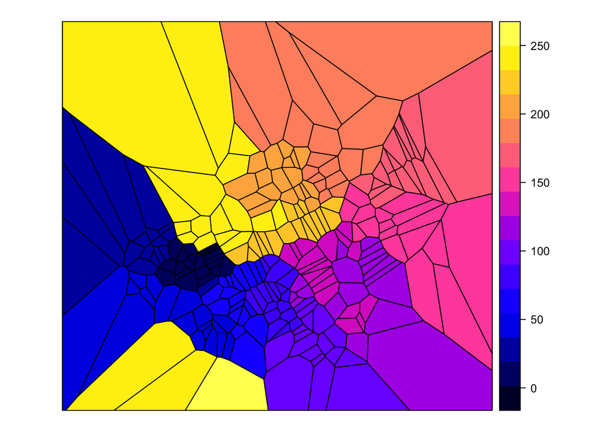

```r
spplot(vor, "id")
```

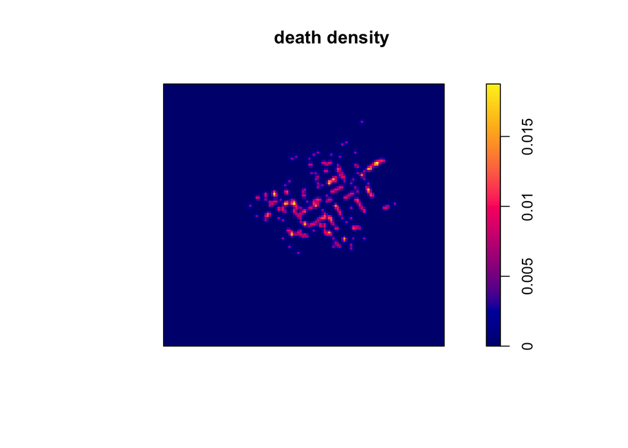

```r
# Kernel Density map
# To get an impression of local spatial variations in intensity, we can plot a kernel estimate of intensity
library(spatstat)
e <- extent(snowMap) # we need a polygon the size of our study area (get the extent from the raster)
# coerce to a SpatialPolygons object
city <- as(e, 'SpatialPolygons')
cityA<-as.owin(city) # needed for the spatstat method to run density kernels

p <- ppp(deaths@coords[,1], deaths@coords[,2], window=cityA)

# ignore number of deaths
ds <- density(p, 5)
plot(ds, main='death density')
```

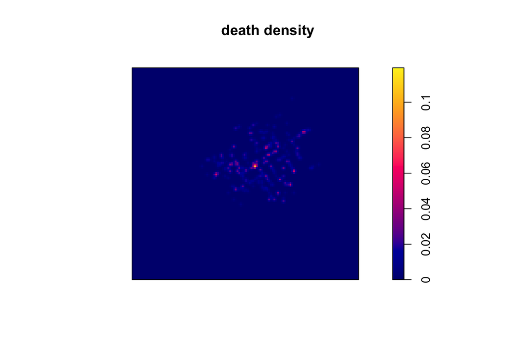

```r
# with number of deaths
ds <- density(p, 5, weights = deaths$Count)
plot(ds, main='death density')
```

```r
## Well done you reached the end of the Cholera exercise in R!
```

## Subselecting your spatial data

Here I will demonstrate two ways for selecting parts of your data: 1) using clip 2) using select

```r
# Select only Pump with ID number 2
red_pumps<-pumps[1,] # select first element
#red_pumps<-pumps[pumps$Id == 2, ]
red_deaths<-deaths[deaths$Count > median(deaths$Count), ]

# create a buffer around the single pump
pump_100m <- gBuffer(red_pumps, width=100, byid=TRUE) # by id creates a buffer around each pump

# Ensure that the result is interpreted as a SpatialPolygon object
pump_100m <- SpatialPolygonsDataFrame(pump_100m, data=pump_100m@data )

# Clip
pump_deaths<-intersect(red_deaths, pump_100m)


# export your map
pdf("snowMap_withDeaths_and_Pumps_clipped.pdf")
plot(snowMap, breaks=cuts, col = pal(7)) #plot with defined breaks
plot(red_deaths, pch = 4, col="red", add=TRUE)
plot(pump_100m, col="green", add=TRUE)
plot(pump_deaths, pch = 5, col="brown", add=TRUE)
plot(red_pumps, pch = 25, col="blue", add=TRUE)
dev.off()
```

## Well done, you survived day 1: 4 more to go!